# Practical Exercise 1

```python
!pip install contextily
import pandas as pd
import numpy as np
import matplotlib.pyplot as plt
import warnings
import geopandas as gpd
import seaborn as sns
from libpysal.weights import DistanceBand, KNN
from esda.moran import Moran
from spreg import OLS, ML_Error, ML_Lag, GM_Error, GM_Lag
from scipy import stats
from shapely.geometry import Point
from splot.esda import moran_scatterplot, plot_moran
import contextily as ctx
from matplotlib.ticker import FuncFormatter
import pyproj
from libpysal.weights import lag_spatial
from scipy.stats import norm
from mgwr.gwr import GWR,MGWR
from mgwr.sel_bw import Sel_BW
import libpysal as ps
from libpysal.weights import Queen
from esda.moran import Moran
import statsmodels.api as sm
```

# Introduction

In this practical exercise, we will explore the factors that influence Airbnb price in Edinburgh. We will do this by fitting a series of spatial regression models. Firstly, a robust spatial regression model, secondly a geographically weighted regression model and finally a multi-scale geographically weighted regression model.

# Data

Data concerning Airbnb listings in Edinburgh was obtained from the Inside Airbnb data archive. The dataset itself dates from the 21st of September 2025.

```python
## Data read and variable selection
df = pd.read_csv('/content/listings.csv')
cols = [
    'id', 'latitude', 'longitude', 'price',
    'accommodates', 'beds', 'bathrooms',
    'review_scores_rating', 'host_since',
    'host_is_superhost',
    'host_response_rate', 'host_acceptance_rate', 'minimum_nights', 'maximum_nights', 'calculated_host_listings_count',
    'number_of_reviews_ltm', 'availability_365', 'estimated_revenue_l365d'
]
df_clean = df[cols].copy()
df_clean.dtypes
```

|  | 0 |
| --- | --- |
| id | int64 |
| latitude | float64 |
| longitude | float64 |
| price | object |
| accommodates | int64 |
| beds | float64 |
| bathrooms | float64 |
| review_scores_rating | float64 |
| host_since | object |
| host_is_superhost | object |
| host_response_rate | object |
| host_acceptance_rate | object |
| minimum_nights | int64 |
| maximum_nights | int64 |
| calculated_host_listings_count | int64 |
| number_of_reviews_ltm | int64 |
| availability_365 | int64 |
| estimated_revenue_l365d | float64 |

**dtype:** object

Having explored the dataset, we selected a dependent variable, a set of meaningful independent variables along with coordinate data with which to construct our spatial regression model. Independent variables were chosen in order to account for the four following criteria; property characteristics, host characteristics, the supply of the property and the demand of the property.

```python
## Data table
variables = {
    'Variable name': [
        'price', 'accommodates', 'beds', 'bathrooms', 'review_scores_rating',
        'host_since', 'host_is_superhost', 'host_acceptance_rate', 'host_response_rate',
        'calculated_host_listings_count', 'minimum_nights', 'maximum_nights',
        'availability_365', 'number_of_reviews_ltm', 'estimated_revenue_l365d'
    ],
    'Type': [
        'Dependent (Y)', 'Property (X)', 'Property (X)', 'Property (X)', 'Property (X)',
        'Host (X)', 'Host (X)', 'Host (X)', 'Host (X)', 'Host (X)',
        'Supply (X)', 'Supply (X)', 'Supply (X)', 'Demand (X)', 'Demand (X)'
    ],
    'Description': [
        'Price per night of property', 'Maximum guest capacity of property',
        'Number of beds of property', 'Number of bathrooms of property',
        'Average review rating score', 'Date host became active',
        'Superhost status of host', 'Rate at which hosts accepts booking',
        'Response rate of host', 'Number of listings host has',
        'Minimum number of nights', 'Maximum number of nights',
        'Availability of property in the last year',
        'Number of reviews the listing has in the last year',
        'Estimated income from the property in the last year'
    ]
}
table = pd.DataFrame(variables)
print(table)
```

```
                     Variable name           Type  \
0                            price  Dependent (Y)
1                     accommodates   Property (X)
2                             beds   Property (X)
3                        bathrooms   Property (X)
4             review_scores_rating   Property (X)
5                       host_since       Host (X)
6                host_is_superhost       Host (X)
7             host_acceptance_rate       Host (X)
8               host_response_rate       Host (X)
9   calculated_host_listings_count       Host (X)
10                  minimum_nights     Supply (X)
11                  maximum_nights     Supply (X)
12                availability_365     Supply (X)
13           number_of_reviews_ltm     Demand (X)
```

[output cut: 18 more lines]

Next we sought to clean our dataset.

```python
## Data clean
## Clean price
df_clean['price'] = df_clean['price'].replace(r'[\$,]', '', regex=True).astype(float)
## Clean calculated_host_listings_count
df_clean.rename(columns={'calculated_host_listings_count' : 'host_listings'}, inplace=True)
## Clean number_of_reviews_ltm
df_clean.rename(columns={'number_of_reviews_ltm' : 'number_of_reviews'}, inplace=True)
## Clean estimated_revenue_l365d
df_clean.rename(columns={'estimated_revenue_l365d' : 'estimated_revenue'}, inplace=True)
## Clean host_since
df_clean['host_since'] = pd.to_datetime(df_clean['host_since'], format='%Y-%m-%d')
df_clean['host_years'] = ((pd.Timestamp.today() - df_clean['host_since']).dt.days / 365).astype(float)
df_clean = df_clean.drop(columns=['host_since'])
## Clean host_is_superhost
df_clean['is_superhost'] = (df_clean['host_is_superhost'] == 't').astype(int)
df_clean = df_clean.drop(columns=['host_is_superhost'])
## Clean host_response_rate
df_clean['host_response_rate'] = df_clean['host_response_rate'].replace(r'[\%,]', '', regex=True).astype(float)
## Clean host_acceptance_rate
df_clean['host_acceptance_rate'] = df_clean['host_acceptance_rate'].replace(r'[\%,]', '', regex=True).astype(float)
df_clean = pd.concat([df_clean], axis=1)
df_clean.shape
```

```
(4936, 19)
```

Having cleaned our data, we dropped any missing values.

```python
## Drop missing values
key_cols = ['price', 'latitude', 'longitude', 'accommodates',
            'beds', 'bathrooms', 'review_scores_rating',
            'host_response_rate', 'host_acceptance_rate', 'minimum_nights', 'maximum_nights', 'host_listings', 'number_of_reviews',
            'availability_365', 'host_years', 'is_superhost', 'estimated_revenue']
df_clean = df_clean.dropna(subset=key_cols)
df_clean.shape
```

```
(4438, 19)
```

Next we explored our 'price' variable.

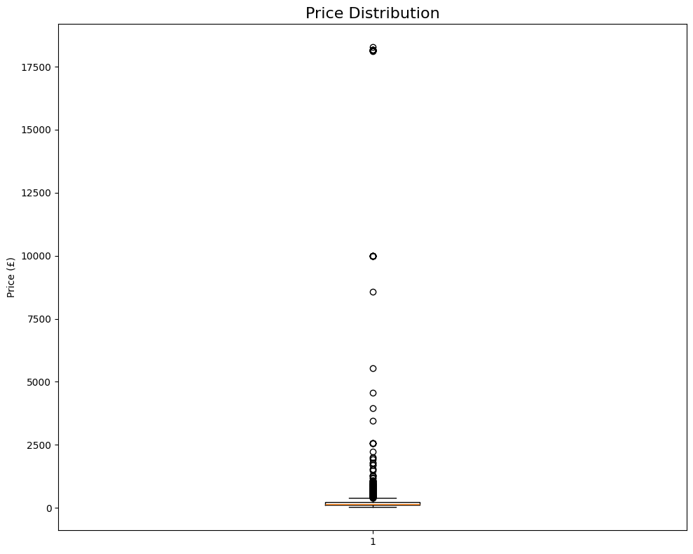

```python
## Explore price outliers
fig, ax = plt.subplots(figsize=(10, 8))
ax.boxplot(df_clean['price'], vert=True)
ax.set_title('Price Distribution', fontsize=16)
ax.set_ylabel('Price (£)')
plt.tight_layout()
plt.show()
```

```python
## Remove price outliers
price_99th = df_clean['price'].quantile(0.99)
df_clean = df_clean[df_clean['price'] <= price_99th]
df_clean = df_clean.reset_index(drop=True)
print(f"99th percentile price: £{price_99th:.2f}")
print(f"After removing top 1%: {len(df_clean)} listings")
```

```
99th percentile price: £1516.31
After removing top 1%: 4393 listings
```

Having observed some outliers, we sought to remove the top percentile of price values.

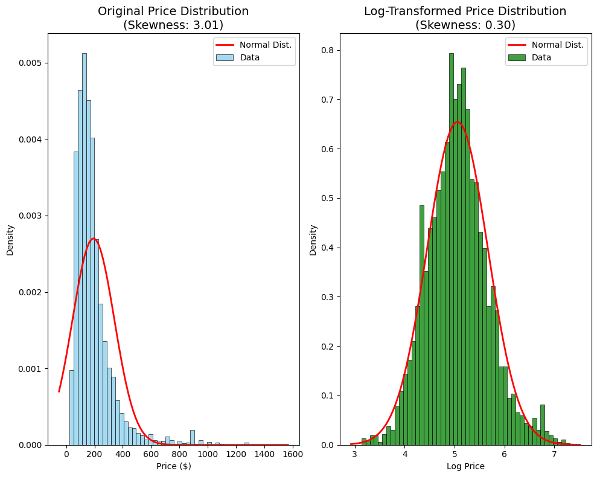

```python
## Log price
df_clean['log_price'] = np.log(df_clean['price'])
price = df_clean['price']
log_price = df_clean['log_price']
fig, axes = plt.subplots(1, 2, figsize=(10, 8))
sns.histplot(price, bins=50, kde=False, color='skyblue', stat='density', ax=axes[0], label='Data')
mu, std = norm.fit(price)
xmin, xmax = axes[0].get_xlim()
x = np.linspace(xmin, xmax, 100)
p = norm.pdf(x, mu, std)
axes[0].plot(x, p, 'r', linewidth=2, label='Normal Dist.')
axes[0].set_title(f'Original Price Distribution\n(Skewness: {price.skew():.2f})', fontsize=14)
axes[0].set_xlabel('Price ($)')
axes[0].legend()
sns.histplot(log_price, bins=50, kde=False, color='green', stat='density', ax=axes[1], label='Data')
mu_log, std_log = norm.fit(log_price)
xmin, xmax = axes[1].get_xlim()
x = np.linspace(xmin, xmax, 100)
p = norm.pdf(x, mu_log, std_log)
axes[1].plot(x, p, 'r', linewidth=2, label='Normal Dist.')
axes[1].set_title(f'Log-Transformed Price Distribution\n(Skewness: {log_price.skew():.2f})', fontsize=14)
axes[1].set_xlabel('Log Price')
axes[1].legend()
plt.tight_layout()
plt.show()
```

Next we log-transformed our ‘price’ variable to reduce skewness and stabilise variance for regression analysis. By comparing the distribution of our two ‘price’ variables we see that by log-transforming price we have a much more symmetric distribution.

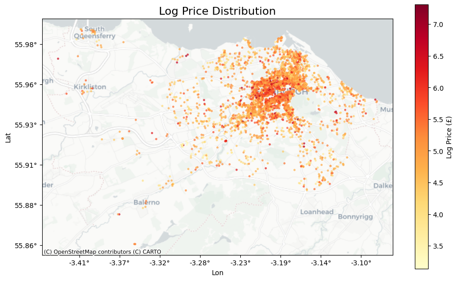

```python
## Log price distribution
geometry = [Point(xy) for xy in zip(df_clean['longitude'], df_clean['latitude'])]
gdf = gpd.GeoDataFrame(df_clean, geometry=geometry, crs='EPSG:4326')
gdf_web = gdf.to_crs('EPSG:3857')
fig, ax = plt.subplots(figsize=(10, 8))
gdf_web.plot(
    ax=ax, column='log_price', cmap='YlOrRd',
    markersize=5, alpha=0.6, legend=True,
    legend_kwds={'label': 'Log Price (£)', 'shrink': 0.7}
)
ctx.add_basemap(ax, source=ctx.providers.CartoDB.Positron)
ax.set_xlabel('Lon')
ax.set_ylabel('Lat')
ax.set_title('Log Price Distribution', fontsize=16)
transformer = pyproj.Transformer.from_crs('EPSG:3857', 'EPSG:4326', always_xy=True)
def lon_formatter(x, pos):
    lon, _ = transformer.transform(x, 0)
    return f'{lon:.2f}°'
def lat_formatter(y, pos):
    _, lat = transformer.transform(0, y)
    return f'{lat:.2f}°'
ax.xaxis.set_major_formatter(FuncFormatter(lon_formatter))
ax.yaxis.set_major_formatter(FuncFormatter(lat_formatter))
plt.tight_layout()
plt.show()
```

By visualising the spatial distribution of our ‘log_price’ variable, it appears that the more expensive Airbnb listings are situated towards the city centre. Furthermore, there is a far greater concentration of Airbnb listings in the city centre than in the peripheral towns and villages.

# Spatial Regression

Before we commenced with regression analysis, we constructed a spatial weight matrix in order to define neighbourhood structure. K-Nearest Neighbours (KNN) was chosen as the primary weight matrix for our regression model as it ensured each observation had at least ‘k’ neighbours. In order for all components to be connected, ‘k’ was chosen to equal 12.

```python
## Spatial Weight Matrix
geometry = [Point(xy) for xy in zip(df_clean['longitude'], df_clean['latitude'])]
gdf = gpd.GeoDataFrame(df_clean, geometry=geometry, crs='EPSG:4326')
gdf = gdf.to_crs('EPSG:27700')
gdf_proj = gdf.to_crs('EPSG:27700')
coords = np.column_stack((gdf_proj.geometry.x, gdf_proj.geometry.y))
w_knn = KNN.from_array(coords, k=12)
w_knn.transform = 'R'
print("=== KNN Spatial Weights (k=12) ===")
print(f"Number of observations: {w_knn.n}")
print(f"Mean number of neighbours: {w_knn.mean_neighbors:.1f}")
print(f"Min neighbours: {w_knn.min_neighbors}")
print(f"Max neighbours: {w_knn.max_neighbors}")
```

[output not shown]

Having constructed a spatial weight matrix, we estimated a standard OLS model as the baseline for which residuals could be examined for spatial autocorrelation. Therefore, we first defined our dependent and independent variables.

```python
## Dependent Variable
y_col = 'log_price'
y = df_clean[[y_col]].values
## Independent variables
x_cols = [
    'accommodates','beds', 'bathrooms',
    'review_scores_rating','host_response_rate', 'host_acceptance_rate',
    'minimum_nights', 'maximum_nights',
    'host_listings', 'number_of_reviews',
    'availability_365', 'host_years', 'is_superhost', 'estimated_revenue']
x = df_clean[x_cols].values
```

Next we ran a Variance Inflation Factor (VIF) check to determine how much the variance of an estimated regression coefficient is increased due to multicollinearity.

```python
## VIF
from statsmodels.stats.outliers_influence import variance_inflation_factor
X_vif = df_clean[x_cols]
vif_data = pd.DataFrame()
vif_data["Variable"] = X_vif.columns
vif_data["VIF"] = [variance_inflation_factor(X_vif.values, i) for i in range(X_vif.shape[1])]
print("Variance Inflation Factor (VIF) Check:")
print("-" * 40)
print(vif_data.sort_values('VIF', ascending=False))
print("-" * 40)
```

```
Variance Inflation Factor (VIF) Check:
----------------------------------------
                Variable         VIF
4     host_response_rate  111.002101
3   review_scores_rating   79.738847
5   host_acceptance_rate   53.402271
0           accommodates   18.744909
1                   beds   11.455581
2              bathrooms    8.280112
11            host_years    7.243909
13     estimated_revenue    3.936284
9      number_of_reviews    3.533562
10      availability_365    3.153919
12          is_superhost    2.376002
7         maximum_nights    1.762813
8          host_listings    1.384289
6         minimum_nights    1.110822
----------------------------------------
```

Our initial check revealed variables 'host_response_rate', 'review_scores_rating', 'host_acceptance_rate' and 'accommodates' to have relatively high VIFs, thus they were removed from our dataset and an updated dataframe created.

```python
## VIF update
x_cols_update = [
    'beds', 'bathrooms',
    'host_years', 'availability_365', 'number_of_reviews',
    'is_superhost', 'maximum_nights', 'minimum_nights', 'host_listings', 'estimated_revenue']
X_vif = df_clean[x_cols_update]
vif_data = pd.DataFrame()
vif_data["Variable"] = X_vif.columns
vif_data["VIF"] = [variance_inflation_factor(X_vif.values, i) for i in range(X_vif.shape[1])]
print("Variance Inflation Factor (VIF) Check:")
print("-" * 40)
print(vif_data.sort_values('VIF', ascending=False))
print("-" * 40)
x_cols = x_cols_update
x = df_clean[x_cols].values
```

```
Variance Inflation Factor (VIF) Check:
----------------------------------------
            Variable       VIF
1          bathrooms  6.256016
2         host_years  4.789928
0               beds  4.419042
9  estimated_revenue  3.627064
4  number_of_reviews  3.100209
3   availability_365  2.720548
5       is_superhost  2.256436
6     maximum_nights  1.711330
8      host_listings  1.318165
7     minimum_nights  1.096444
----------------------------------------
```

A second VIF check revealed that mutlicollinearity was no longer a concern for our regression analysis.

```python
## OLS 1
ols1 = OLS(
    y, x,
    w=w_knn,
    name_y=y_col,
    name_x=x_cols,
    name_ds='Edinburgh Airbnb',
    spat_diag=True)
print(ols1.summary)
```

```
REGRESSION RESULTS
------------------

SUMMARY OF OUTPUT: ORDINARY LEAST SQUARES
-----------------------------------------
Data set            :Edinburgh Airbnb
Weights matrix      :     unknown
Dependent Variable  :   log_price                Number of Observations:        4393
Mean dependent var  :      5.0602                Number of Variables   :          11
S.D. dependent var  :      0.6098                Degrees of Freedom    :        4382
R-squared           :      0.5254
Adjusted R-squared  :      0.5243
Sum squared residual:     775.129                F-statistic           :    485.0370
Sigma-square        :       0.177                Prob(F-statistic)     :           0
S.E. of regression  :       0.421                Log likelihood        :   -2423.046
Sigma-square ML     :       0.176                Akaike info criterion :    4868.092
S.E of regression ML:      0.4201                Schwarz criterion     :    4938.357

------------------------------------------------------------------------------------
            Variable     Coefficient       Std.Error     t-Statistic     Probability
------------------------------------------------------------------------------------
            CONSTANT         4.57426         0.02489       183.81133         0.00000
                beds         0.11188         0.00528        21.18796         0.00000
           bathrooms         0.09147         0.01230         7.43419         0.00000
          host_years        -0.00252         0.00182        -1.38291         0.16676
    availability_365         0.00035         0.00006         6.05011         0.00000
   number_of_reviews        -0.00931         0.00030       -30.61837         0.00000
        is_superhost         0.00177         0.01385         0.12791         0.89823
      maximum_nights         0.00002         0.00002         1.39092         0.16432
      minimum_nights        -0.00215         0.00071        -3.01909         0.00255
       host_listings         0.00383         0.00037        10.34653         0.00000
   estimated_revenue         0.00001         0.00000        37.59335         0.00000
------------------------------------------------------------------------------------

REGRESSION DIAGNOSTICS
MULTICOLLINEARITY CONDITION NUMBER          11.786

TEST ON NORMALITY OF ERRORS
TEST                             DF        VALUE           PROB
Jarque-Bera                       2       2589.057           0.0000
```

[output cut: 9 more lines]

```
TEST                              DF       VALUE           PROB
Lagrange Multiplier (lag)         1       1248.968           0.0000
Robust LM (lag)                   1        215.298           0.0000
Lagrange Multiplier (error)       1       1354.542           0.0000
Robust LM (error)                 1        320.873           0.0000
Lagrange Multiplier (SARMA)       2       1569.841           0.0000

- Spatial Durbin -
TEST                              DF       VALUE           PROB
LM test for WX                   10        407.503           0.0000
Robust LM WX test                10        513.077           0.0000
Lagrange Multiplier (lag)         1       1248.968           0.0000
Robust LM Lag - SDM               1       1354.542           0.0000
Joint test for SDM               11       1762.045           0.0000
================================ END OF REPORT =====================================
```

Having run our initial OLS regression model, the decision was made to remove the variable 'estimated_revenue', given it is partially determined by listing price and may introduce endogeneity. We then ran an updated OLS regression model.

```python
## OLS 2
x_cols_update = [
    'beds', 'bathrooms',
    'host_years', 'availability_365', 'number_of_reviews',
    'is_superhost', 'maximum_nights', 'minimum_nights', 'host_listings']
x_cols = x_cols_update
x = df_clean[x_cols].values
ols2 = OLS(
    y, x,
    w=w_knn,
    name_y=y_col,
    name_x=x_cols,
    name_ds='Edinburgh Airbnb',
    spat_diag=True)
print(ols2.summary)
```

```
REGRESSION RESULTS
------------------

SUMMARY OF OUTPUT: ORDINARY LEAST SQUARES
-----------------------------------------
Data set            :Edinburgh Airbnb
Weights matrix      :     unknown
Dependent Variable  :   log_price                Number of Observations:        4393
Mean dependent var  :      5.0602                Number of Variables   :          10
S.D. dependent var  :      0.6098                Degrees of Freedom    :        4383
R-squared           :      0.3723
Adjusted R-squared  :      0.3710
Sum squared residual:     1025.12                F-statistic           :    288.8347
Sigma-square        :       0.234                Prob(F-statistic)     :           0
S.E. of regression  :       0.484                Log likelihood        :   -3037.045
Sigma-square ML     :       0.233                Akaike info criterion :    6094.090
S.E of regression ML:      0.4831                Schwarz criterion     :    6157.967

------------------------------------------------------------------------------------
            Variable     Coefficient       Std.Error     t-Statistic     Probability
------------------------------------------------------------------------------------
            CONSTANT         4.39502         0.02809       156.48848         0.00000
                beds         0.17489         0.00576        30.37520         0.00000
           bathrooms         0.17493         0.01392        12.57053         0.00000
          host_years         0.00069         0.00209         0.33149         0.74029
    availability_365         0.00053         0.00007         8.06390         0.00000
   number_of_reviews        -0.00319         0.00030       -10.80235         0.00000
        is_superhost         0.09339         0.01568         5.95649         0.00000
      maximum_nights         0.00001         0.00002         0.75898         0.44791
      minimum_nights        -0.00123         0.00082        -1.50927         0.13130
       host_listings         0.00419         0.00043         9.85518         0.00000
------------------------------------------------------------------------------------

REGRESSION DIAGNOSTICS
MULTICOLLINEARITY CONDITION NUMBER          10.895

TEST ON NORMALITY OF ERRORS
TEST                             DF        VALUE           PROB
Jarque-Bera                       2       2512.312           0.0000

```

[output cut: 8 more lines]

```
TEST                              DF       VALUE           PROB
Lagrange Multiplier (lag)         1       2037.728           0.0000
Robust LM (lag)                   1        117.384           0.0000
Lagrange Multiplier (error)       1       2354.545           0.0000
Robust LM (error)                 1        434.201           0.0000
Lagrange Multiplier (SARMA)       2       2471.929           0.0000

- Spatial Durbin -
TEST                              DF       VALUE           PROB
LM test for WX                    9        404.004           0.0000
Robust LM WX test                 9        720.821           0.0000
Lagrange Multiplier (lag)         1       2037.728           0.0000
Robust LM Lag - SDM               1       2354.545           0.0000
Joint test for SDM               10       2758.549           0.0000
================================ END OF REPORT =====================================
```

An R2 statistic of 0.372 for our OLS regresion model indicates that our model explains only 37.2% of the variation in log-transformed price. Only variables, beds, bathrooms, availability_365, number_of_reviews, is_superhost and host_listings were significant.

Next we mapped our OLS residuals with Global Moran's I as a diagnostic step to determine if we can use spatial regression.

[figure not shown]

```python
## Mapping residuals
df_clean['ols_residuals'] = ols2.u
gdf_res = gpd.GeoDataFrame(
    df_clean,
    geometry=gpd.points_from_xy(df_clean.longitude, df_clean.latitude),
    crs="EPSG:4326")
fig, ax = plt.subplots(figsize=(10, 8))
gdf_res_proj = gdf_res.to_crs(epsg=3857)
gdf_res_proj.plot(
    column='ols_residuals',
    scheme='std_mean',
    k=12,
    cmap='coolwarm',
    legend=True,
    ax=ax,
    markersize=15,
    alpha=0.8)
ctx.add_basemap(ax, source=ctx.providers.CartoDB.Positron)
ax.set_title('Spatial Distribution of OLS Residuals\n(Clusters indicate Spatial Autocorrelation)', fontsize=15)
ax.set_axis_off()
plt.tight_layout()
plt.show()
```

Clusters of high residuals in the city centre and clusters of low residuals in the peripheral areas of the city indicates spatial autocorrelation.

```python
## Moran's I test
residuals = ols2.u.flatten()
moran = Moran(residuals, w_knn)
print("=== Global Moran's I Test on OLS Residuals ===")
print(f"Moran's I:     {moran.I:.4f}")
print(f"Expected I:    {moran.EI:.4f}")
print(f"Z-score:       {moran.z_sim:.4f}")
print(f"P-value:       {moran.p_sim:.4f}")
print()
```

```
=== Global Moran's I Test on OLS Residuals ===
Moran's I:     0.2826
Expected I:    -0.0002
Z-score:       49.8949
P-value:       0.0010
```

Furthermore, a statistically significant Global Moran's I test result of our OLS residuals indicates that 'location' is a missing variable that OLS is failing to account for.

Following on from this we ran three spatial regression models: a Spatial Error model (SEM), a Spatial Autoregressive/Lag model (SAR) and a Spatial Durbin model (SDM).

```python
## SEM model
sem = ML_Error(
    y, x,
    w=w_knn,
    name_y=y_col,
    name_x=x_cols,
    name_ds='Edinburgh Airbnb (SEM)'
)
```

```python
## SAR model
sar = ML_Lag(
    y, x,
    w=w_knn,
    name_y=y_col,
    name_x=x_cols,
    name_ds='Edinburgh Airbnb (SAR)'
)
```

```python
## SDM model
wx_cols = ['W_' + col for col in x_cols]
wx_array = np.column_stack([lag_spatial(w_knn, x[:, i]) for i in range(x.shape[1])])
x_sdm = np.hstack([x, wx_array])
x_sdm_names = x_cols + wx_cols
sdm = ML_Lag(
    y, x_sdm,
    w=w_knn,
    name_y=y_col,
    name_x=x_sdm_names,
    name_ds='Edinburgh Airbnb (SDM)'
)
```

A Likelihood ratio test can be used to formally determine whether the SDM can be simplified down to an SEM or SAR.

```python
## Likelihood Ratio test
print("=" * 60)
print("LIKELIHOOD RATIO (LR) TESTS")
print("=" * 60)
lr_sdm_sar = -2 * (sar.logll - sdm.logll)
df_diff_sar = len(x_cols)  # number of WX variables added
p_sdm_sar = 1 - stats.chi2.cdf(lr_sdm_sar, df_diff_sar)
print(f"\nLR Test: SDM vs SAR")
print(f"  H0: θ = 0 (spatially lagged X variables are unnecessary)")
print(f"  LR statistic: {lr_sdm_sar:.4f}")
print(f"  Degrees of freedom: {df_diff_sar}")
print(f"  P-value: {p_sdm_sar:.4f}")
if p_sdm_sar < 0.05:
    print("  → Reject H0: SDM is preferred over SAR")
else:
    print("  → Cannot reject H0: SAR is sufficient (SDM not needed)")
lr_sdm_sem = -2 * (sem.logll - sdm.logll)
df_diff_sem = len(x_cols) + 1  # WX terms + rho
p_sdm_sem = 1 - stats.chi2.cdf(lr_sdm_sem, df_diff_sem)
print(f"\nLR Test: SDM vs SEM")
print(f"  H0: θ + ρβ = 0 (common factor hypothesis)")
print(f"  LR statistic: {lr_sdm_sem:.4f}")
print(f"  Degrees of freedom: {df_diff_sem}")
print(f"  P-value: {p_sdm_sem:.4f}")
if p_sdm_sem < 0.05:
    print("  → Reject H0: SDM is preferred over SEM")
else:
    print("  → Cannot reject H0: SEM is sufficient (SDM not needed)")
print("\n" + "=" * 60)
print("FINAL MODEL RECOMMENDATION")
print("=" * 60)
if p_sdm_sar < 0.05 and p_sdm_sem < 0.05:
    print("→ SDM is preferred: Both SAR and SEM are rejected in favour of SDM.")
elif p_sdm_sar >= 0.05 and p_sdm_sem < 0.05:
    print("→ SAR is preferred: SDM does not significantly improve over SAR.")
elif p_sdm_sar < 0.05 and p_sdm_sem >= 0.05:
    print("→ SEM is preferred: SDM does not significantly improve over SEM.")
else:
    print("→ Either SAR or SEM may be sufficient. Choose based on AIC and theory.")
```

```
============================================================
LIKELIHOOD RATIO (LR) TESTS
============================================================

LR Test: SDM vs SAR
  H0: θ = 0 (spatially lagged X variables are unnecessary)
  LR statistic: 139.4377
  Degrees of freedom: 9
  P-value: 0.0000
  → Reject H0: SDM is preferred over SAR

LR Test: SDM vs SEM
  H0: θ + ρβ = 0 (common factor hypothesis)
  LR statistic: 85.8546
  Degrees of freedom: 10
  P-value: 0.0000
  → Reject H0: SDM is preferred over SEM

============================================================
FINAL MODEL RECOMMENDATION
============================================================
→ SDM is preferred: Both SAR and SEM are rejected in favour of SDM.
```

In this instance, we can determine that the SDM is preferred over the SEM and SAR. Now we can print the results for our Spatial Durbin model.

```python
## SDM model summary
print(sdm.summary)
```

```
REGRESSION RESULTS
------------------

SUMMARY OF OUTPUT: MAXIMUM LIKELIHOOD SPATIAL LAG (METHOD = FULL)
-----------------------------------------------------------------
Data set            :Edinburgh Airbnb (SDM)
Weights matrix      :     unknown
Dependent Variable  :   log_price                Number of Observations:        4393
Mean dependent var  :      5.0602                Number of Variables   :          20
S.D. dependent var  :      0.6098                Degrees of Freedom    :        4373
Pseudo R-squared    :      0.5249
Spatial Pseudo R-squared:  0.4382
Log likelihood      :  -2496.1028
Sigma-square ML     :      0.1769                Akaike info criterion :    5032.206
S.E of regression   :      0.4206                Schwarz criterion     :    5159.961

------------------------------------------------------------------------------------
            Variable     Coefficient       Std.Error     z-Statistic     Probability
------------------------------------------------------------------------------------
            CONSTANT         1.58649         0.10361        15.31280         0.00000
                beds         0.16106         0.00507        31.78845         0.00000
           bathrooms         0.17468         0.01220        14.31793         0.00000
          host_years        -0.00597         0.00186        -3.21764         0.00129
    availability_365         0.00039         0.00006         6.76738         0.00000
   number_of_reviews        -0.00401         0.00026       -15.34663         0.00000
        is_superhost         0.08117         0.01389         5.84251         0.00000
      maximum_nights         0.00002         0.00002         1.47964         0.13897
      minimum_nights        -0.00071         0.00071        -0.99199         0.32120
       host_listings         0.00122         0.00040         3.07665         0.00209
              W_beds        -0.05748         0.01508        -3.81141         0.00014
         W_bathrooms        -0.11220         0.03540        -3.16932         0.00153
        W_host_years         0.01724         0.00466         3.69807         0.00022
  W_availability_365         0.00024         0.00016         1.50247         0.13298
 W_number_of_reviews         0.00462         0.00071         6.52114         0.00000
      W_is_superhost        -0.01418         0.03545        -0.40007         0.68911
    W_maximum_nights        -0.00003         0.00005        -0.64856         0.51662
    W_minimum_nights        -0.00295         0.00237        -1.24705         0.21238
     W_host_listings         0.00281         0.00089         3.16564         0.00155
         W_log_price         0.57566         0.02137        26.94074         0.00000
------------------------------------------------------------------------------------
```

[output cut: 8 more lines]

```
   number_of_reviews        -0.0040         -0.0054         -0.0095
        is_superhost         0.0812          0.1101          0.1913
      maximum_nights         0.0000          0.0000          0.0001
      minimum_nights        -0.0007         -0.0010         -0.0017
       host_listings         0.0012          0.0017          0.0029
              W_beds        -0.0575         -0.0780         -0.1355
         W_bathrooms        -0.1122         -0.1522         -0.2644
        W_host_years         0.0172          0.0234          0.0406
  W_availability_365         0.0002          0.0003          0.0006
 W_number_of_reviews         0.0046          0.0063          0.0109
      W_is_superhost        -0.0142         -0.0192         -0.0334
    W_maximum_nights        -0.0000         -0.0000         -0.0001
    W_minimum_nights        -0.0030         -0.0040         -0.0070
     W_host_listings         0.0028          0.0038          0.0066
================================ END OF REPORT =====================================
```

A Pseudo R2 of 0.525 indicates that the model now explains 52.5% of the variation in the log-transformed Airbnb prices.

The spatial autoregressive coefficient (0.58) is positive and significant, suggesting a positive spatial dependence in Airbnb Listing Price.

In this SDM model, only w_beds, w_bathrooms, w_host_years, w_number_of_reviews and w_host_listings are significant.

The direct impact of w_beds is -0.0575, which means that if your neighbours have one more bed, your log airbnb price will go down by 0.0575. The indirect impact is -0.0780 suggesting that when your neighbours get more beds, it creates an overall log airbnb price drop for all its neighbours by 0.0780. The overall impact of adding a bed to the airbnb price market is therefore -0.1355.

For w_bathrooms, the direct impact is -0.1122, the indirect impact is -0.1522 resulting in an overall impact of -0.2644.

For w_host_years, the direct impact is 0.0172, the indirect impact is 0.0234 resulting in an overall impact of 0.0406.

For w_number_of_reviews, the direct impact is 0.0046, the indirect impact is 0.0063 resulting in an overall impact of 0.0109.

For w_host_listings, the direct impact is 0.0028, the indirect impact is 0.0038 resulting in an overall impact of 0.0066.

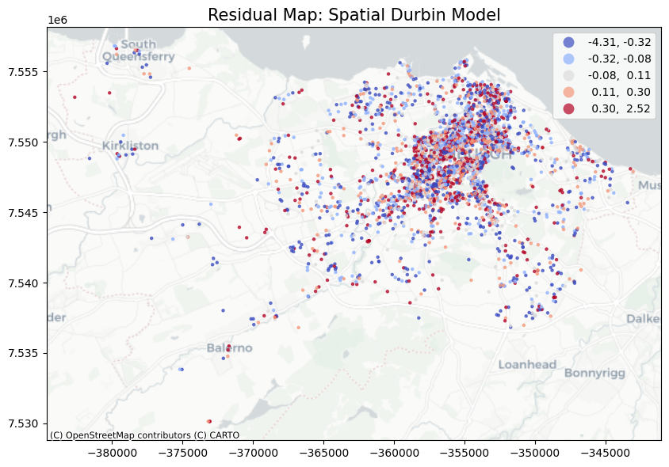

```python
## SDM model residual map
target_column = 'sdm_resid'
gdf_web['sdm_resid'] = sdm.u
fig, ax = plt.subplots(figsize=(10, 8))
gdf_web.plot(
    column=target_column,
    cmap='coolwarm',
    scheme='quantiles',
    k=5,
    markersize=5,
    legend=True,
    ax=ax,
    alpha=0.7
)
ctx.add_basemap(ax, source=ctx.providers.CartoDB.Positron)
ax.set_title(f'Residual Map: Spatial Durbin Model', fontsize=15)
plt.show()
```

In comparison to our earlier map of the spatial distribution of our OLS regression model residuals, we see less clustering.

```python
## SDM model Moran's I
residuals = sdm.u.flatten()
moran = Moran(residuals, w_knn)
print("=== Global Moran's I Test on SDM Residuals ===")
print(f"Moran's I:     {moran.I:.4f}")
print(f"Expected I:    {moran.EI:.4f}")
print(f"Z-score:       {moran.z_sim:.4f}")
print(f"P-value:       {moran.p_sim:.4f}")
print()
```

```
=== Global Moran's I Test on SDM Residuals ===
Moran's I:     -0.0091
Expected I:    -0.0002
Z-score:       -1.5364
P-value:       0.0540
```

By running a test for spatial autocorrelation in our residuals we received a global Moran's I of -0.0091 and a p-value of 0.054. Overall, this indicates that residuals are spatially random.

# Geographically Weighted Regression

Next we look to run a Geographically Weighted Regression (GWR) analysis. Firstly we re-selected and standardised our dependent and independent variables and then identified the optimal bandwidth.

```python
## GWR bandwidth selection
x_cols = [
    'beds', 'bathrooms',
    'host_years', 'availability_365', 'number_of_reviews',
    'is_superhost', 'maximum_nights', 'minimum_nights', 'host_listings']
x = df_clean[x_cols].values
y_col = 'log_price'
y = df_clean[[y_col]].values
x = (x - x.mean(axis=0))/x.std(axis=0)
y = (y - y.mean(axis=0))/y.std(axis=0)
gwr_selector = Sel_BW(coords, y, x,)
gwr_bw = gwr_selector.search(verbose=True,criterion='AICc')
print("Selected optimal bandwidth is:", gwr_bw)
```

```
Bandwidth:  1715.0 , score:  9455.99
Bandwidth:  2738.0 , score:  9771.23
Bandwidth:  1083.0 , score:  9221.59
Bandwidth:  692.0 , score:  9083.52
Bandwidth:  451.0 , score:  9021.20
Bandwidth:  301.0 , score:  8976.54
Bandwidth:  209.0 , score:  8932.32
Bandwidth:  152.0 , score:  8961.28
Bandwidth:  244.0 , score:  8947.86
Bandwidth:  187.0 , score:  8934.13
Bandwidth:  222.0 , score:  8936.61
Bandwidth:  200.0 , score:  8931.58
Bandwidth:  195.0 , score:  8931.55
Bandwidth:  192.0 , score:  8932.57
Bandwidth:  197.0 , score:  8932.40
Bandwidth:  194.0 , score:  8932.31
Bandwidth:  196.0 , score:  8932.08
Selected optimal bandwidth is: 195.0
```

The selected optimal bandwidth is 195 (meaning that 195 nearest neighbours are used for each local regression), which is fitted to our GWR model.

```python
## GWR model
gwr_results = GWR(coords, y, x, bw=gwr_bw,name_x=x_cols).fit()
gwr_results.summary()
```

```
===========================================================================
Model type                                                         Gaussian
Number of observations:                                                4393
Number of covariates:                                                    10

Global Regression Results
---------------------------------------------------------------------------
Residual sum of squares:                                           2757.534
Log-likelihood:                                                   -5210.541
AIC:                                                              10441.082
AICc:                                                             10443.142
BIC:                                                             -34006.051
R2:                                                                   0.372
Adj. R2:                                                              0.371

Variable                              Est.         SE  t(Est/SE)    p-value
------------------------------- ---------- ---------- ---------- ----------
Intercept                            0.000      0.012      0.000      1.000
beds                                 0.430      0.014     30.375      0.000
bathrooms                            0.177      0.014     12.571      0.000
host_years                           0.004      0.012      0.331      0.740
availability_365                     0.100      0.012      8.064      0.000
number_of_reviews                   -0.137      0.013    -10.802      0.000
is_superhost                         0.077      0.013      5.956      0.000
maximum_nights                       0.009      0.012      0.759      0.448
minimum_nights                      -0.018      0.012     -1.509      0.131
host_listings                        0.124      0.013      9.855      0.000

Geographically Weighted Regression (GWR) Results
---------------------------------------------------------------------------
Spatial kernel:                                           Adaptive bisquare
Bandwidth used:                                                     195.000

Diagnostic information
---------------------------------------------------------------------------
Residual sum of squares:                                           1451.057
Effective number of parameters (trace(S)):                          576.805
Degree of freedom (n - trace(S)):                                  3816.195
Sigma estimate:                                                       0.617
Log-likelihood:                                                   -3800.290
```

[output cut: 8 more lines]

```
Summary Statistics For GWR Parameter Estimates
---------------------------------------------------------------------------
Variable                   Mean        STD        Min     Median        Max
-------------------- ---------- ---------- ---------- ---------- ----------
Intercept                 0.016      0.350     -1.245     -0.007      0.710
beds                      0.430      0.164     -0.197      0.436      0.999
bathrooms                 0.213      0.146     -0.184      0.203      0.840
host_years               -0.005      0.146     -0.315     -0.029      0.746
availability_365          0.063      0.095     -0.189      0.052      0.572
number_of_reviews        -0.195      0.088     -0.609     -0.183     -0.009
is_superhost              0.075      0.108     -0.263      0.069      0.443
maximum_nights            0.014      0.067     -0.233      0.015      0.176
minimum_nights           -0.284      0.769     -5.126     -0.178      3.279
host_listings             0.040      0.200     -1.688      0.040      0.781
===========================================================================
```

An adjusted R2 value of 0.62 indicates that our model now explains approximately 62% of the variation in the log-transformed price of Airbnb listings in Edinburgh.

```python
## GWR residuals
w = Queen.from_dataframe(gdf_web)
w.transform = 'R'
residual_moran = Moran(gwr_results.resid_response.reshape(-1), w)
residual_moran.I
```

```
np.float64(0.04344081059023671)
```

A Moran's I result of 0.0434 indicates very weak spatial clustering.

```python
## GWR inference visualisation
from mpl_toolkits.axes_grid1 import make_axes_locatable
from mgwr.utils import shift_colormap,truncate_colormap
from matplotlib import cm,colors
def param_plots(result, gdf, names=[], filter_t=False, figsize=(10, 10)):
    k = gwr_results.k
    fig, axs = plt.subplots(int(k/2)+1, 2, figsize=figsize)
    axs = axs.ravel()
    vmin = -0.8
    vmax = 0.8
    cmap = cm.get_cmap("bwr_r")
    norm = colors.BoundaryNorm(np.arange(-0.8,0.9,0.1),ncolors=256)
    for j in range(k):
        pd.concat([gdf,pd.DataFrame(np.hstack([result.params,result.bse]))],axis=1).plot(ax=axs[j],column=j,vmin=vmin,vmax=vmax,cmap=cmap,norm=norm,linewidth=0.1,edgecolor='white',aspect=1)
        axs[j].set_title("Parameter estimates of \n" + names[j],fontsize=10)
        axs[j].set_axis_off()
        if filter_t:
            rslt_filtered_t = result.filter_tvals()
            if (rslt_filtered_t[:,j] == 0).any():
                gdf[rslt_filtered_t[:,j] == 0].plot(color='lightgrey', ax=axs[j],linewidth=0.1,edgecolor='white',aspect=1)
                ctx.add_basemap(axs[j],source=ctx.providers.CartoDB.Positron)

    for j in range (k,len(axs)):
      axs[j].set_visible(False)

    fig = axs[j].get_figure()
    cax = fig.add_axes([0.99, 0.2, 0.025, 0.6])
    sm = plt.cm.ScalarMappable(cmap=cmap,norm=norm)
    sm._A = []
    fig.colorbar(sm, cax=cax)

    plt.tight_layout()
    plt.show()
```

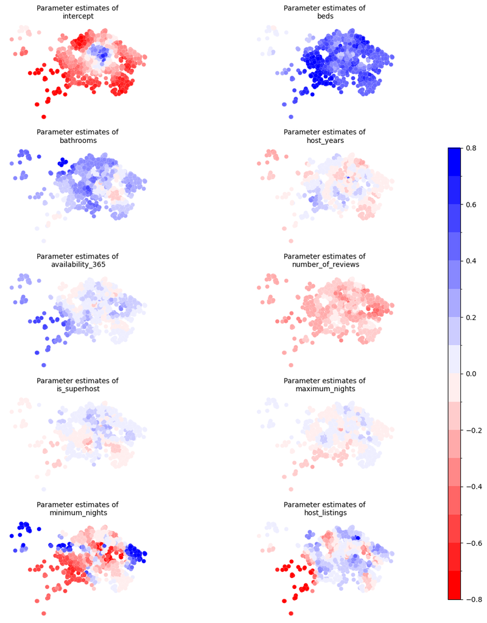

```python
## GWR visualisation
param_plots(gwr_results, gdf_web, names=['intercept'] + x_cols, figsize = (10,15))
```

- Price increases as a result of the addition of a bed is strong and positive across the city, but the strength of that increase varies by location. It is slightly lower in the city centre.
- Price increases as a result of the addition of a bathroom is relatively weak and positive across the city, but the strength of that increase varies by location. It is slightly lower towards the east of the city and higher in the west.
- Price increases as a result of the number of reviews is relatively weak and negative across the city, but the strength of that increase varies by location. It is slightly higher towards the east of the city centre.
- Price increases as a result of the minimum number of nights a listing is available varies across the city. The strength of the relationship is strong and positive towards the east and north west and strong and negative in the city centre and south west (being weak towards the north and south of the city centre).
- Price increases as a result of the number of listings a host has is relatively weak apart from the west where it is comparatively strong and negative.
- Price increases as a result of the years a host has been active, availability, superhost status or the maximum number of nights a listing is available is relatively weak.

# Multiscale Geographically Weighted Regression

Next we ran a Multiscale Geographically Weighted Regression model. Again, we first searched for the optimal bandwidth with which to fit each parameter in our model.

```python
## MGWR bandwidth selection
mgwr_selector = Sel_BW(coords, y, x, multi=True)
mgwr_bw = mgwr_selector.search(verbose=True)
print("Selected optimal bandwidth is:", mgwr_bw)
```

```
Current iteration: 1 ,SOC: 0.003688
Bandwidths: 60.0, 101.0, 165.0, 100.0, 135.0, 756.0, 397.0, 4247.0, 99.0, 527.0
Current iteration: 2 ,SOC: 0.0014639
Bandwidths: 60.0, 87.0, 200.0, 89.0, 119.0, 1707.0, 583.0, 4256.0, 99.0, 754.0
Current iteration: 3 ,SOC: 0.0006256
Bandwidths: 60.0, 86.0, 206.0, 89.0, 104.0, 1891.0, 689.0, 4269.0, 99.0, 918.0
Current iteration: 4 ,SOC: 0.000473
Bandwidths: 60.0, 86.0, 242.0, 89.0, 104.0, 3123.0, 697.0, 4269.0, 99.0, 1153.0
Current iteration: 5 ,SOC: 0.0003516
Bandwidths: 60.0, 86.0, 262.0, 89.0, 104.0, 4386.0, 697.0, 4269.0, 99.0, 1154.0
Current iteration: 6 ,SOC: 0.000242
Bandwidths: 60.0, 86.0, 266.0, 89.0, 99.0, 4390.0, 697.0, 4269.0, 99.0, 1154.0
Current iteration: 7 ,SOC: 0.0001716
Bandwidths: 60.0, 86.0, 266.0, 89.0, 99.0, 4390.0, 697.0, 4269.0, 99.0, 1154.0
Current iteration: 8 ,SOC: 0.0001327
Bandwidths: 60.0, 86.0, 266.0, 89.0, 99.0, 4390.0, 697.0, 4269.0, 99.0, 1154.0
Current iteration: 9 ,SOC: 0.0001056
Bandwidths: 60.0, 86.0, 266.0, 89.0, 99.0, 4390.0, 689.0, 4269.0, 99.0, 1154.0
Current iteration: 10 ,SOC: 8.68e-05
Bandwidths: 60.0, 86.0, 271.0, 89.0, 99.0, 4390.0, 689.0, 4269.0, 99.0, 1154.0
Current iteration: 11 ,SOC: 6.78e-05
Bandwidths: 60.0, 86.0, 271.0, 89.0, 99.0, 4390.0, 689.0, 4269.0, 99.0, 1154.0
Current iteration: 12 ,SOC: 5.38e-05
Bandwidths: 60.0, 86.0, 271.0, 89.0, 99.0, 4390.0, 689.0, 4269.0, 99.0, 1154.0
Current iteration: 13 ,SOC: 4.31e-05
Bandwidths: 60.0, 86.0, 271.0, 89.0, 99.0, 4390.0, 689.0, 4269.0, 99.0, 1154.0
Current iteration: 14 ,SOC: 3.47e-05
Bandwidths: 60.0, 86.0, 271.0, 89.0, 99.0, 4390.0, 689.0, 4269.0, 99.0, 1154.0
Current iteration: 15 ,SOC: 2.81e-05
Bandwidths: 60.0, 86.0, 271.0, 89.0, 99.0, 4390.0, 689.0, 4269.0, 99.0, 1154.0
Current iteration: 16 ,SOC: 2.28e-05
Bandwidths: 60.0, 86.0, 271.0, 89.0, 99.0, 4390.0, 689.0, 4269.0, 99.0, 1154.0
Current iteration: 17 ,SOC: 1.86e-05
Bandwidths: 60.0, 86.0, 271.0, 89.0, 99.0, 4390.0, 689.0, 4269.0, 99.0, 1154.0
Current iteration: 18 ,SOC: 1.52e-05
Bandwidths: 60.0, 86.0, 271.0, 89.0, 99.0, 4390.0, 689.0, 4269.0, 99.0, 1154.0
Current iteration: 19 ,SOC: 1.25e-05
Bandwidths: 60.0, 86.0, 271.0, 89.0, 99.0, 4390.0, 689.0, 4269.0, 99.0, 1154.0
Current iteration: 20 ,SOC: 1.03e-05
Bandwidths: 60.0, 86.0, 271.0, 89.0, 99.0, 4390.0, 689.0, 4269.0, 99.0, 1154.0
Current iteration: 21 ,SOC: 8.5e-06
Bandwidths: 60.0, 86.0, 271.0, 89.0, 99.0, 4390.0, 689.0, 4269.0, 99.0, 1154.0
Selected optimal bandwidth is: [  60.   86.  271.   89.   99. 4390.  689. 4269.   99. 1154.]
```

The optimal bandwidths were selected to fit our MWGR model.

```python
## MGWR model
mgwr_results = MGWR(coords, y, x, selector=mgwr_selector,name_x=x_cols).fit()
mgwr_results.summary()
```

```
===========================================================================
Model type                                                         Gaussian
Number of observations:                                                4393
Number of covariates:                                                    10

Global Regression Results
---------------------------------------------------------------------------
Residual sum of squares:                                           2757.534
Log-likelihood:                                                   -5210.541
AIC:                                                              10441.082
AICc:                                                             10443.142
BIC:                                                             -34006.051
R2:                                                                   0.372
Adj. R2:                                                              0.371

Variable                              Est.         SE  t(Est/SE)    p-value
------------------------------- ---------- ---------- ---------- ----------
Intercept                            0.000      0.012      0.000      1.000
beds                                 0.430      0.014     30.375      0.000
bathrooms                            0.177      0.014     12.571      0.000
host_years                           0.004      0.012      0.331      0.740
availability_365                     0.100      0.012      8.064      0.000
number_of_reviews                   -0.137      0.013    -10.802      0.000
is_superhost                         0.077      0.013      5.956      0.000
maximum_nights                       0.009      0.012      0.759      0.448
minimum_nights                      -0.018      0.012     -1.509      0.131
host_listings                        0.124      0.013      9.855      0.000

Multi-Scale Geographically Weighted Regression (MGWR) Results
---------------------------------------------------------------------------
Spatial kernel:                                           Adaptive bisquare
Criterion for optimal bandwidth:                                       AICc
Score of Change (SOC) type:                                     Smoothing f
Termination criterion for MGWR:                                       1e-05

MGWR bandwidths
---------------------------------------------------------------------------
Variable             Bandwidth      ENP_j   Adj t-val(95%)   Adj alpha(95%)
Intercept               60.000    192.004            3.655            0.000
beds                    86.000    124.814            3.542            0.000
```

[output cut: 22 more lines]

```
Summary Statistics For MGWR Parameter Estimates
---------------------------------------------------------------------------
Variable                   Mean        STD        Min     Median        Max
-------------------- ---------- ---------- ---------- ---------- ----------
Intercept                 0.026      0.369     -0.917      0.008      0.906
beds                      0.426      0.187     -0.330      0.432      1.116
bathrooms                 0.234      0.113     -0.020      0.232      0.521
host_years               -0.014      0.156     -0.376     -0.027      0.792
availability_365          0.068      0.123     -0.238      0.059      0.825
number_of_reviews        -0.184      0.001     -0.190     -0.184     -0.184
is_superhost              0.074      0.057     -0.039      0.066      0.192
maximum_nights            0.013      0.003     -0.005      0.014      0.017
minimum_nights           -0.240      0.673     -3.592     -0.207      2.564
host_listings             0.027      0.044     -0.059      0.021      0.162
===========================================================================
```

An adjusted R2 value of 0.656 indicates that our model now accounts for 65.6% of variation.

```python
## MGWR residuals
w = Queen.from_dataframe(gdf_web)
w.transform = 'R'
residual_moran = Moran(mgwr_results.resid_response.reshape(-1), w)
residual_moran.I
```

```
np.float64(-0.01650010058304348)
```

A Moran's I result of -0.0165 indicates very weak spatial clustering.

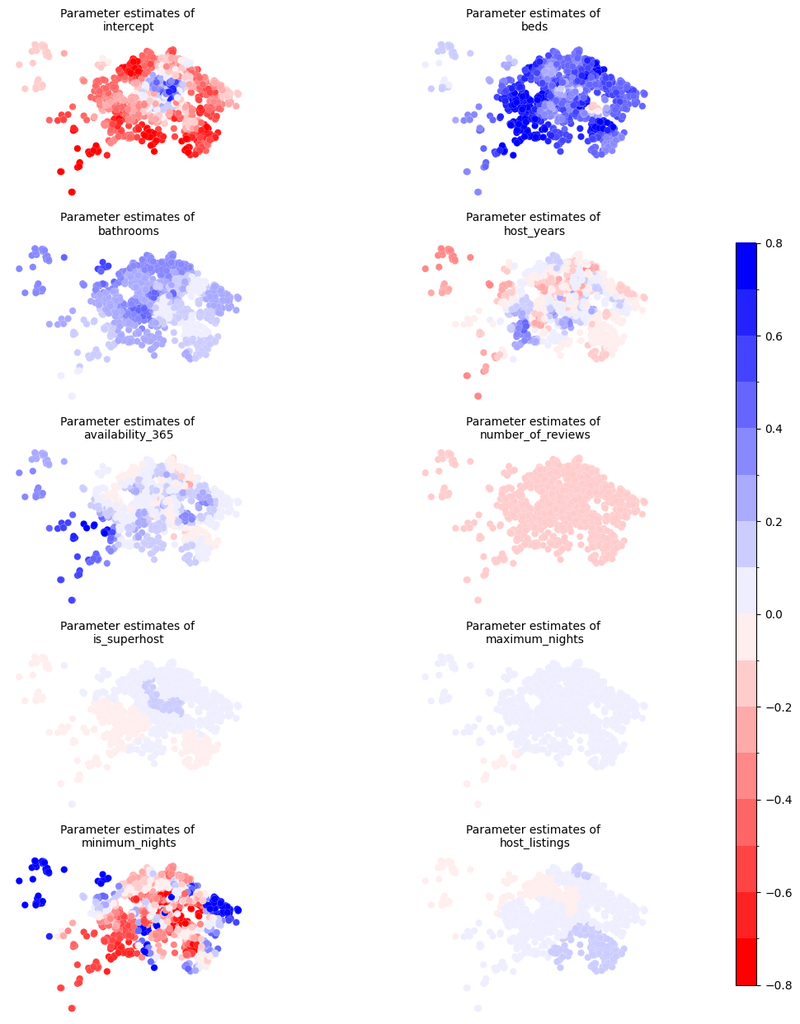

```python
## MGWR visualisation
param_plots(mgwr_results, gdf_web, names=['intercept'] + x_cols ,figsize = (10,15))
```

# Conclusion

```python
## Comparison of OLS, GWR and MGWR models
comp = {
    'OLS': [
        'R2 = 0.371', 'AICc = 6094.090', 'Morans I = 0.2826'
    ],
    'SDM' : [
        'Pseudo R2 = 0.525', 'AICc = 5032.206', 'Morans I = -0.0091'
    ],
    'GWR': [
        'R2 = 0.620', 'AICc = 8931.554', 'Morans I = 0.0434'
    ],
    'MGWR': [
        'R2 = 0.656', 'AICc = 8692.386', 'Morans I = -0.0165'
    ]
}

table2 = pd.DataFrame(comp)
print(table2)
```

```
                 OLS                 SDM                GWR  \
0         R2 = 0.371   Pseudo R2 = 0.525         R2 = 0.620
1    AICc = 6094.090     AICc = 5032.206    AICc = 8931.554
2  Morans I = 0.2826  Morans I = -0.0091  Morans I = 0.0434

                 MGWR
0          R2 = 0.656
1     AICc = 8692.386
2  Morans I = -0.0165
```

Our initial OLS model only explained 37.1% of the variation in the price of Airbnb listings in Edinburgh. The SDM improved on this, explaining 52.5% of variation and the GWR and MGWR models saw even greater improvement in explanatory power (0.620 and 0.656 respectively). Spatial autocorrelation is all but eliminated in our final three models where it was previously present in our OLS model as indicated by our Moran's I result. A higher AICc may indicate however that our later GWR and MGWR models do not explain our data as well.

## Word count

1534